# ReMoTe simulation: Mixing Ackley

04 February, 2022, 17:48

## Background

We initialize a population of size one million using the ARI, and age structure that mimics South Africa. We then generate new case of disease over a one year period and explore the role of reinfection in generating new cases of disease. We simulate populations with prevalence ranging from 100/100k to 1000/100k.

We use the correction in our calculations that true prevalence should be 1.66 times reported to account for smear negative TB.

We explore varying two main parameters: 1. The risk of progression to disease as a function of the number of infections. 2. The proportion of the population that is at high risk of infection.

## Parameters used in this simulation

### Risk of progression to disease

Following is a depiction of the parameters used for the risk of progression to disease for those with a new infection as a function of the number of total infections.

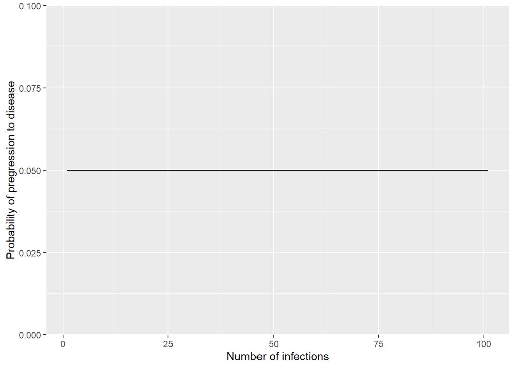

### Proportion of the population at high risk

In this simulation, we assume that 0.8 proportion of the population are at low risk of infection.

In summary the parameters for the simulation are:

| Prev(per100k) | Overall ARI | Population Low Risk | Prob progress with 1 infection | Probability with 2 infections | increase per addt’l infection |
| --- | --- | --- | --- | --- | --- |
| 100 | 0.90 | 0.8 | 0.05 | 0.02 | 0.01 |
| 200 | 1.27 | 0.8 | 0.05 | 0.02 | 0.01 |
| 300 | 1.63 | 0.8 | 0.05 | 0.02 | 0.01 |
| 400 | 2.00 | 0.8 | 0.05 | 0.02 | 0.01 |
| 500 | 2.36 | 0.8 | 0.05 | 0.02 | 0.01 |
| 600 | 2.72 | 0.8 | 0.05 | 0.02 | 0.01 |
| 700 | 3.10 | 0.8 | 0.05 | 0.02 | 0.01 |
| 800 | 3.46 | 0.8 | 0.05 | 0.02 | 0.01 |
| 900 | 3.83 | 0.8 | 0.05 | 0.02 | 0.01 |
| 1000 | 4.20 | 0.8 | 0.05 | 0.02 | 0.01 |

## Parameter sweep to determine ARI

We perform a parameter sweep to determine the ARI that would create the observed ARI that Dodd used to correlate with prevalence.

More specifically, Dodd et al determined that the ARIs that would correspond to the prevalences of 100/100k,…, 1000/100k are 0.009, 0.0127, 0.0163, 0.02, 0.0236, 0.0272, 0.031, 0.0346, 0.0383, 0.042. These ARI were measured from uninfected children. Therefore, in our simulation, we seek to determine the true ARI that would produce this observed ARI among those who are uninfected at the start of our one year simulation. To do this for each prevalence assumed, we initialize the population using a broad range of ARIs and then generate cases. We count the number of individuals uninfected at the start of the simulation year and then the number of new cases among these individuals and calculate the ARI from these individuals and call this the observed ARI. We select the underlying ARI that produces an observed ARI that most closely matches the Dodd et al estimate.

We note that the observed ARI for the scenario where individuals mix homogeneously should be the same as the Dodd estimate. This is because the ARI is uniformly applied to all uninfected at the start of the one year simulation and this becomes an unbiased estimator of the ARI.

When there is variation in the risk of exposure, as we have simulated in our heterogeneous mixing scenario, then the ARI is biased. If we assume that $p^{lo}$ and $p^{hi}$ of the high and low risk populations, respectively, are uninfected at the start of the simulation, then these are described as the probability of escaping infection for each year an individual is alive. For instance, if we have $N^{lo}_a$ individuals that are $a$ years old in the low risk group, then

$p^{lo}=\sum_a^A N_a (1-\lambda^{lo})^a.$

This is similarly defined for $p^{hi}$. The observed ARI in any given year among the uninfected is

$\lambda^{obs}=\frac{\text{New Infections at time t+1}}{\text{Number uninfected at time t}}=\frac{\lambda^{lo}p^{lo}0.8+\lambda^{hi}p^{hi}0.2}{0.8p^{lo}+0.2p^{hi}}.$

Because $p^{lo] \ne p^{hi}$, this is not comparable to the ARI that generates the infections in the simulation.

### ARIs estimated from parameter sweep

We perform a sweep through many candidate ARI values to determine the underlying ARI that would produce observed ARIs that are used by Dodd to link the ARI to prevalence. Following are the results.

| Prev(per100k) | Correct Prev | overall ARI | low risk ARI | high risk ARI | ARI observed |
| --- | --- | --- | --- | --- | --- |
| 100 | 166 | 1.13 | 0.565 | 3.39 | 0.8972551 |
| 200 | 332 | 1.71 | 0.855 | 5.13 | 1.2717808 |
| 300 | 498 | 2.29 | 1.145 | 6.87 | 1.6279709 |
| 400 | 664 | 2.91 | 1.455 | 8.73 | 1.9998586 |
| 500 | 830 | 3.52 | 1.760 | 10.56 | 2.3619464 |
| 600 | 996 | 4.13 | 2.065 | 12.39 | 2.7225706 |
| 700 | 1162 | 4.77 | 2.385 | 14.31 | 3.1004520 |
| 800 | 1328 | 5.38 | 2.690 | 16.14 | 3.4605983 |
| 900 | 1494 | 6.01 | 3.005 | 18.03 | 3.8326785 |
| 1000 | 1660 | 6.63 | 3.315 | 19.89 | 4.1989793 |

## Initializing the population

We first determine the number of infections that individuals have at the start of the simulation.

### Results of initialized population

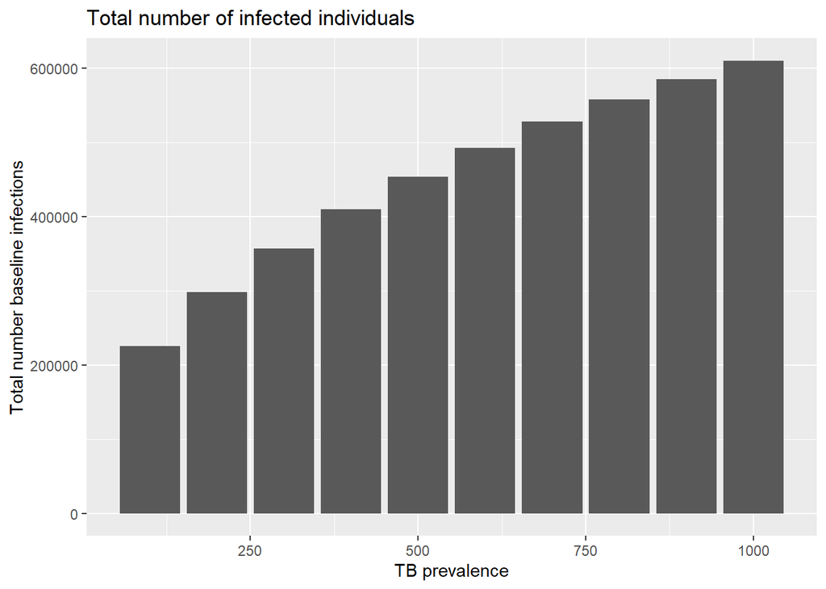

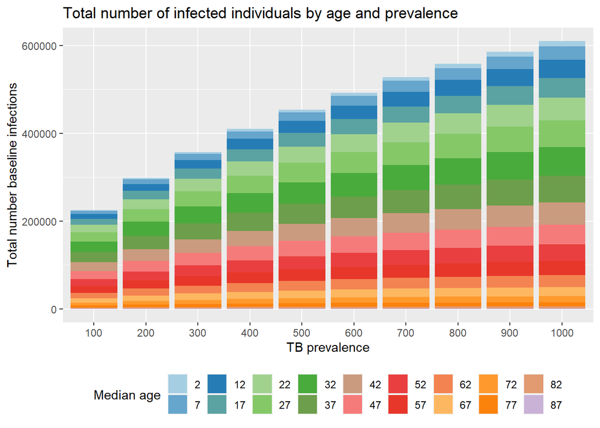

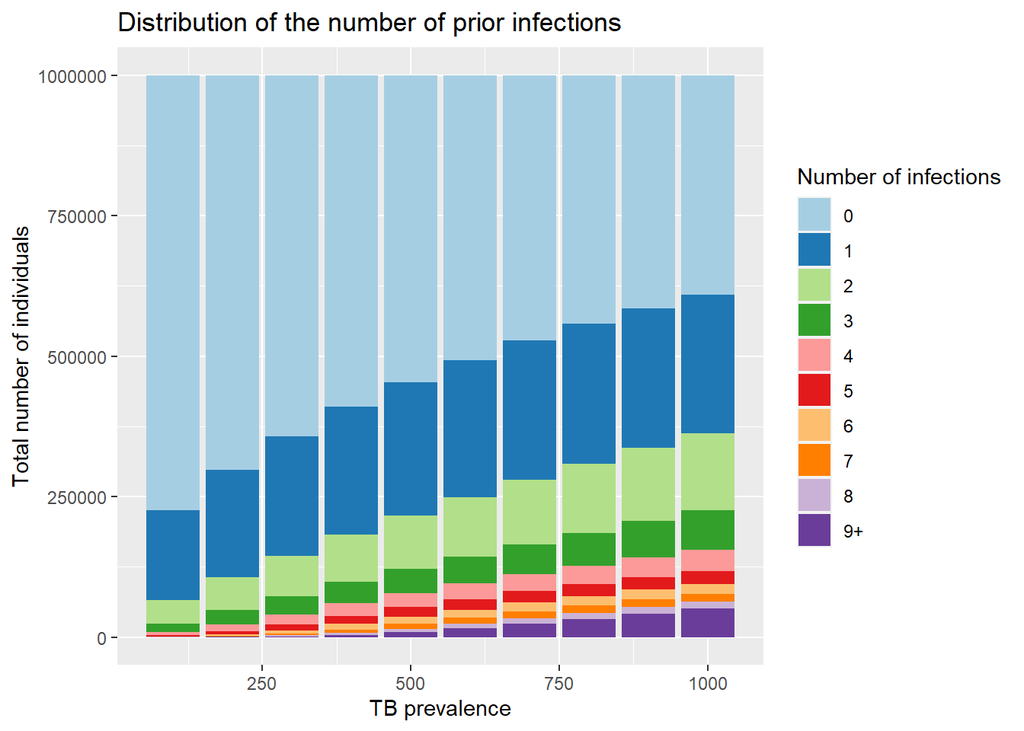

We focus in on those with at least six prior infections in this plot.

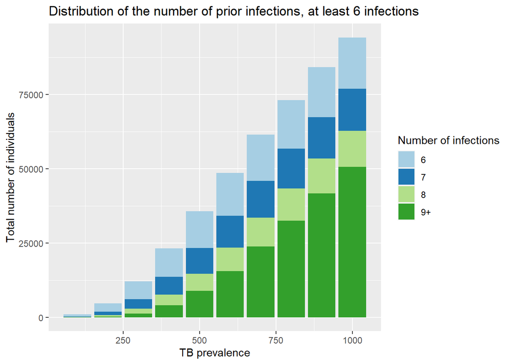

We show the prevalence of LTBI by age and TB disease prevalence. This can be compared to the Dodd et al data.

Prevalence of LTBI by age and TB prevalence

|  | Prev100 | Prev200 | Prev300 | Prev400 | Prev500 | Prev600 | Prev700 | Prev800 | Prev900 | Prev1000 |
| --- | --- | --- | --- | --- | --- | --- | --- | --- | --- | --- |
| 0-4 | 0.02 | 0.03 | 0.04 | 0.05 | 0.07 | 0.08 | 0.09 | 0.10 | 0.11 | 0.12 |
| 5-9 | 0.07 | 0.11 | 0.14 | 0.17 | 0.20 | 0.22 | 0.25 | 0.27 | 0.30 | 0.32 |
| 10-14 | 0.12 | 0.17 | 0.22 | 0.26 | 0.30 | 0.33 | 0.36 | 0.39 | 0.42 | 0.44 |
| 15-19 | 0.16 | 0.22 | 0.28 | 0.33 | 0.37 | 0.41 | 0.45 | 0.48 | 0.51 | 0.54 |
| 20-24 | 0.20 | 0.27 | 0.33 | 0.39 | 0.44 | 0.48 | 0.52 | 0.55 | 0.58 | 0.61 |
| 25-29 | 0.23 | 0.31 | 0.38 | 0.44 | 0.49 | 0.53 | 0.58 | 0.61 | 0.64 | 0.67 |
| 30-34 | 0.26 | 0.35 | 0.42 | 0.49 | 0.54 | 0.58 | 0.63 | 0.66 | 0.69 | 0.72 |
| 35-39 | 0.29 | 0.39 | 0.46 | 0.53 | 0.58 | 0.63 | 0.67 | 0.70 | 0.74 | 0.77 |
| 40-44 | 0.32 | 0.42 | 0.49 | 0.56 | 0.62 | 0.66 | 0.71 | 0.74 | 0.77 | 0.80 |
| 45-49 | 0.35 | 0.45 | 0.53 | 0.59 | 0.65 | 0.70 | 0.74 | 0.77 | 0.81 | 0.83 |
| 50-54 | 0.37 | 0.47 | 0.55 | 0.62 | 0.68 | 0.73 | 0.77 | 0.80 | 0.83 | 0.86 |
| 55-59 | 0.39 | 0.50 | 0.58 | 0.65 | 0.71 | 0.75 | 0.79 | 0.83 | 0.86 | 0.88 |
| 60-64 | 0.41 | 0.52 | 0.60 | 0.67 | 0.73 | 0.78 | 0.82 | 0.85 | 0.88 | 0.90 |
| 65-69 | 0.43 | 0.54 | 0.63 | 0.70 | 0.75 | 0.80 | 0.84 | 0.87 | 0.89 | 0.91 |
| 70-74 | 0.45 | 0.56 | 0.65 | 0.72 | 0.77 | 0.82 | 0.86 | 0.88 | 0.91 | 0.93 |
| 75-79 | 0.47 | 0.58 | 0.67 | 0.74 | 0.79 | 0.84 | 0.87 | 0.90 | 0.92 | 0.94 |
| 80-84 | 0.48 | 0.60 | 0.69 | 0.76 | 0.81 | 0.85 | 0.89 | 0.91 | 0.93 | 0.95 |
| 85+ | 0.50 | 0.62 | 0.70 | 0.77 | 0.83 | 0.87 | 0.90 | 0.92 | 0.94 | 0.96 |

We also show the total number of infections and total number of times individuals have been infected by risk category.

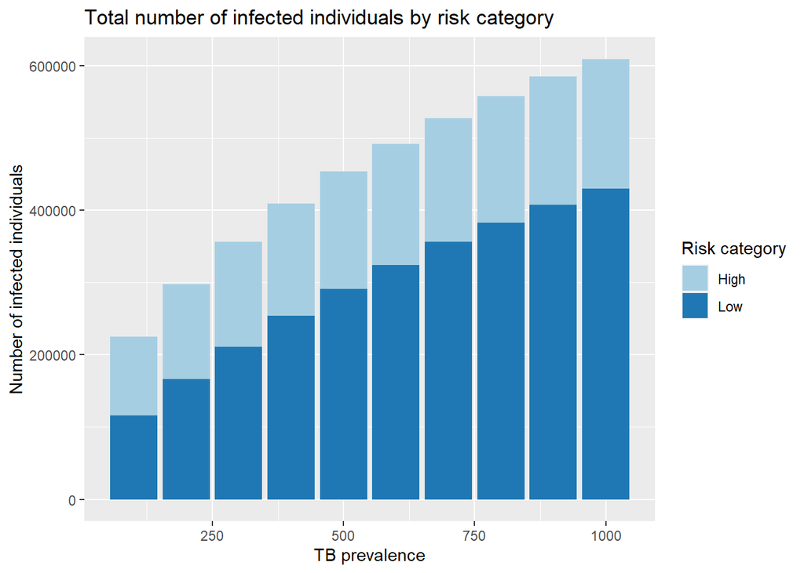

We can also consider the number of infections individuals have by prevalence and risk category.

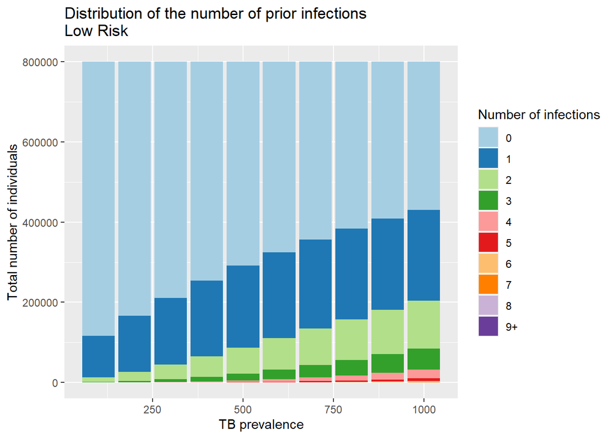

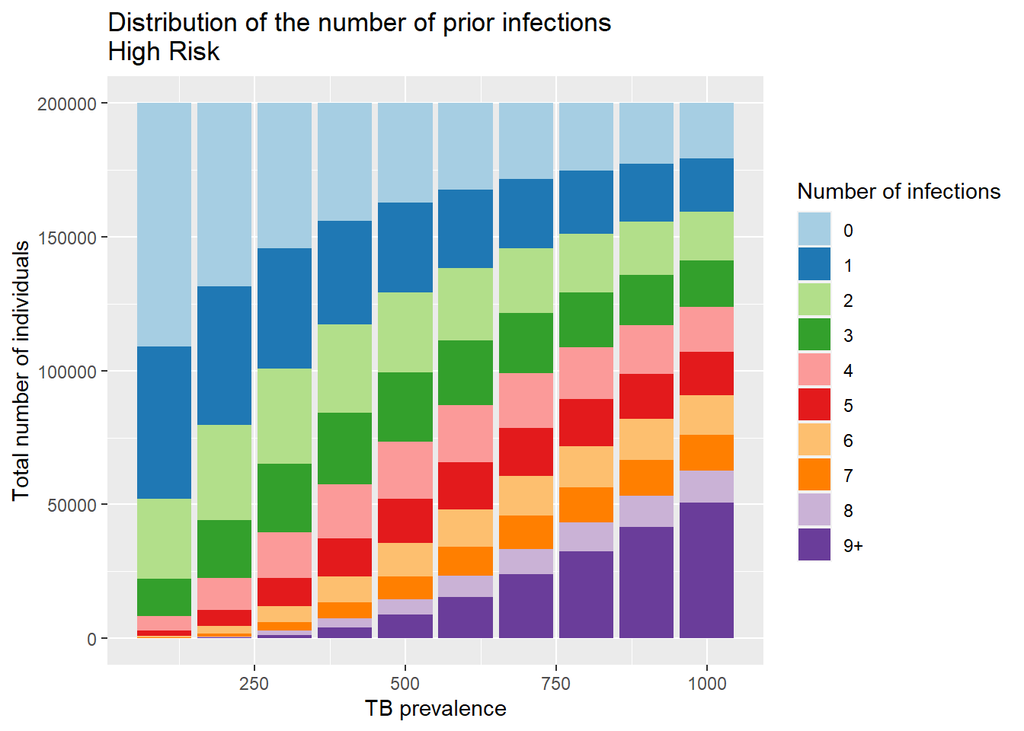

## New cases generated over one year

We can calculate the following statistics (the first 6 only apply to the mixing scenarios):

- Cases from first infection, low risk
- Cases from reinfection, low risk
- Total cases, low risk
- Cases from first infection, high risk
- Cases from reinfection, high risk
- Total cases, high risk
- Cases from old infection (all in high risk)
- Total cases
- percent cases from first infection
- percent cases from old infection
- Corrected prevalence (=1.66*smear positive prevalence)
- Incidence (per 100000)
- Implied duration (=prev/Inc)
- Reproductive number for infection (= #new infections/corrected prevalence)
- Reproductive number for disease (= #ATB from new infections/corrected prevalence)

We also look at overall and by risk category, as appropriate:

- Uninfected individuals at start of simulation
- Number infected during one year
- Observed ARI

| Prevalence (/100k) | low risk: ATB from first inf | low risk: ATB from reinfection | low risk: total ATB | high risk: ATB from first int | high risk: ATB from reinfection | high risk: total ATB | ATB from old infections | Total ATB | percent first inf | percent old inf | corrected prevalence | incidence (per 100,000) | duration | Rt infections | Rt disease |
| --- | --- | --- | --- | --- | --- | --- | --- | --- | --- | --- | --- | --- | --- | --- | --- |
| 100 | 193.1408 | 13.94467 | 207.0854 | 154.4611 | 103.2631 | 257.7242 | 76.56940 | 541.379 | 0.6420674 | 0.1414340 | 166 | 54.1379 | 3.066244 | 68.07229 | 2.800058 |
| 200 | 270.8499 | 31.11377 | 301.9637 | 175.5500 | 219.4437 | 394.9937 | 90.97459 | 787.932 | 0.5665462 | 0.1154600 | 332 | 78.7932 | 4.213562 | 51.50602 | 2.099269 |
| 300 | 337.1127 | 54.45690 | 391.5696 | 186.3579 | 372.6432 | 559.0011 | 99.00549 | 1049.576 | 0.4987447 | 0.0943290 | 498 | 104.9576 | 4.744772 | 45.98393 | 1.908777 |
| 400 | 397.3731 | 85.82020 | 483.1933 | 193.0231 | 576.0485 | 769.0716 | 103.73952 | 1356.004 | 0.4353940 | 0.0765038 | 664 | 135.6004 | 4.896739 | 43.82530 | 1.885941 |
| 500 | 447.7635 | 122.78948 | 570.5529 | 197.2636 | 815.6267 | 1012.8903 | 106.13960 | 1689.583 | 0.3817671 | 0.0628200 | 830 | 168.9583 | 4.912455 | 42.40964 | 1.907763 |
| 600 | 490.7939 | 165.52776 | 656.3217 | 200.3004 | 1094.1185 | 1294.4189 | 107.16556 | 2057.906 | 0.3358240 | 0.0520750 | 996 | 205.7906 | 4.839871 | 41.46586 | 1.958575 |
| 700 | 529.3381 | 216.30763 | 745.6457 | 202.7108 | 1428.0348 | 1630.7456 | 107.28649 | 2483.678 | 0.2947439 | 0.0431966 | 1162 | 248.3678 | 4.678546 | 41.04991 | 2.045087 |
| 800 | 560.8114 | 270.16268 | 830.9741 | 204.5019 | 1786.0241 | 1990.5260 | 106.78425 | 2928.284 | 0.2613521 | 0.0364665 | 1328 | 292.8284 | 4.535079 | 40.51205 | 2.124624 |
| 900 | 588.8024 | 331.19698 | 919.9994 | 205.9568 | 2196.4254 | 2402.3822 | 105.82049 | 3428.202 | 0.2318297 | 0.0308676 | 1494 | 342.8202 | 4.357970 | 40.22758 | 2.223816 |
| 1000 | 612.5834 | 396.49046 | 1009.0738 | 207.0653 | 2640.6509 | 2847.7163 | 104.54921 | 3961.339 | 0.2069120 | 0.0263924 | 1660 | 396.1339 | 4.190502 | 39.93976 | 2.323367 |

We also calculate the observed ARI.

| Prevalence | Overall: Uninfected | Low: Uninfected | High: Uninfected | Overall: New infections | Low: New infections | High: New Infections | Overall: Obs ARI | Low: Obs ARI | High: Obs ARI |
| --- | --- | --- | --- | --- | --- | --- | --- | --- | --- |
| 100 | 774811.6 | 683684.2 | 91127.47 | 6952.037 | 3862.816 | 3089.221 | 0.0089726 | 0.00565 | 0.0339 |
| 200 | 702007.6 | 633567.1 | 68440.54 | 8927.998 | 5416.999 | 3511.000 | 0.0127178 | 0.00855 | 0.0513 |
| 300 | 643095.7 | 588843.1 | 54252.67 | 10469.412 | 6742.253 | 3727.158 | 0.0162797 | 0.01145 | 0.0687 |
| 400 | 590437.9 | 546217.3 | 44220.64 | 11807.923 | 7947.461 | 3860.462 | 0.0199986 | 0.01455 | 0.0873 |
| 500 | 546182.6 | 508822.1 | 37360.53 | 12900.541 | 8955.269 | 3945.272 | 0.0236195 | 0.01760 | 0.1056 |
| 600 | 507677.8 | 475345.2 | 32332.59 | 13821.885 | 9815.878 | 4006.007 | 0.0272257 | 0.02065 | 0.1239 |
| 700 | 472220.7 | 443889.4 | 28331.34 | 14640.977 | 10586.762 | 4054.215 | 0.0310045 | 0.02385 | 0.1431 |
| 800 | 442301.2 | 416960.2 | 25341.00 | 15306.266 | 11216.228 | 4090.038 | 0.0346060 | 0.02690 | 0.1614 |
| 900 | 414727.8 | 391881.8 | 22846.01 | 15895.183 | 11776.048 | 4119.135 | 0.0383268 | 0.03005 | 0.1803 |
| 1000 | 390403.8 | 369582.7 | 20821.05 | 16392.974 | 12251.668 | 4141.307 | 0.0419898 | 0.03315 | 0.1989 |

### Plotting the results

We show the number of TB disease cases by prevalence and source (old infection, new primary infection, re-infection).

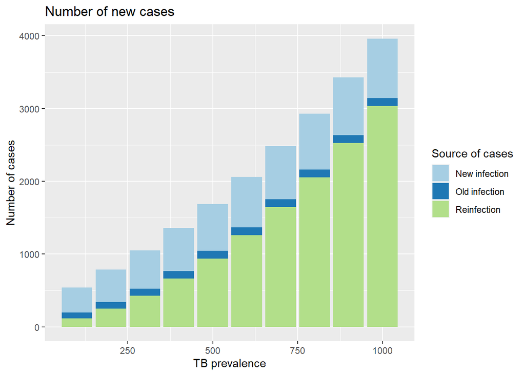